# Analise de Dados

Grupo 2 - Arnaldo, Gabriel, Marcello

2023-11-20

# Descrição do problema e análise das métricas de desempenho

# Input da Base e ajustes básicos

```r
df <- read.csv("C:/Users/arnch/OneDrive/Documentos/Insper/healthcare-dataset-stroke-data.csv")

df  %>%
   lapply(type_sum) %>%
   as_tibble() %>%
   pivot_longer(cols = 1:ncol(df),
                names_to = "Coluna",
               values_to = "Tipo") %>%
   inner_join(
    df %>%
       summarise(across(everything(), ~sum(is.na(.)))) %>%
       pivot_longer(cols = 1:ncol(df),
                    names_to = "Coluna",
                   values_to = "Total NA")
  )
```

```
## # A tibble: 12 × 3
##    Coluna            Tipo  `Total NA`
##    <chr>             <chr>      <int>
##  1 id                int            0
##  2 gender            chr            0
##  3 age               dbl            0
##  4 hypertension      int            0
##  5 heart_disease     int            0
##  6 ever_married      chr            0
##  7 work_type         chr            0
##  8 Residence_type    chr            0
##  9 avg_glucose_level dbl            0
## 10 bmi               chr            0
## 11 smoking_status    chr            0
## 12 stroke            int            0
```

```r
df %>% head(5)  %>% glimpse()
```

```
## Rows: 5
## Columns: 12
## $ id                <int> 9046, 51676, 31112, 60182, 1665
## $ gender            <chr> "Male", "Female", "Male", "Female", "Female"
## $ age               <dbl> 67, 61, 80, 49, 79
## $ hypertension      <int> 0, 0, 0, 0, 1
## $ heart_disease     <int> 1, 0, 1, 0, 0
## $ ever_married      <chr> "Yes", "Yes", "Yes", "Yes", "Yes"
## $ work_type         <chr> "Private", "Self-employed", "Private", "Private", "S…
## $ Residence_type    <chr> "Urban", "Rural", "Rural", "Urban", "Rural"
## $ avg_glucose_level <dbl> 228.7, 202.2, 105.9, 171.2, 174.1
## $ bmi               <chr> "36.6", "N/A", "32.5", "34.4", "24"
## $ smoking_status    <chr> "formerly smoked", "never smoked", "never smoked", "…
## $ stroke            <int> 1, 1, 1, 1, 1
```

```r
df %>% skim() %>% View()

print(paste("Percentual de casos com derrames:", 100 * (df %>% filter(stroke == 1) %>% nrow() / nrow(df))))
```

```
## [1] "Percentual de casos com derrames: 4.87279843444227"
```

arruma os tipos das variáveis

```r
df <- df %>%
  mutate(
          gender = as.factor(gender),
          hypertension = as.factor(hypertension),
          heart_disease = as.factor(heart_disease),
          ever_married = as.factor(ever_married),
          work_type = as.factor(work_type),
          Residence_type = as.factor(Residence_type),
          smoking_status = as.factor(smoking_status),
          stroke = as.factor(stroke)
          )

df$bmi %>% table() %>% sort(decreasing = TRUE) %>% head()
```

```
## .
##  N/A 28.7 28.4 26.1 26.7 27.6
##  201   41   38   37   37   37
```

```r
#criamos feature flag
df$flag <- ifelse(df$bmi == "N/A", 1, 0)

df$bmi <- ifelse(df$bmi == "N/A", NA, df$bmi)

df <- df %>%
  mutate(
          flag = as.factor(flag),
          bmi = as.double(bmi),
          )

df %>% dplyr::select(bmi, flag) %>% head(5) %>% glimpse()
```

```
## Rows: 5
## Columns: 2
## $ bmi  <dbl> 36.6, NA, 32.5, 34.4, 24.0
## $ flag <fct> 0, 1, 0, 0, 0
```

Exclusão de categoria com representatividade muito baixa

```r
# input de dados ----------------------------------------------------------
categorical_variables <- df %>%
  select_if(is.factor) %>%
  names()

for (i in categorical_variables) {
  cat("Variable:", i, "\n")
  print(table(df[[i]]))
  cat("\n")
}
```

```
## Variable: gender
##
## Female   Male  Other
##   2994   2115      1
##
## Variable: hypertension
##
##    0    1
## 4612  498
##
## Variable: heart_disease
##
##    0    1
## 4834  276
##
## Variable: ever_married
##
##   No  Yes
## 1757 3353
##
## Variable: work_type
##
##      children      Govt_job  Never_worked       Private Self-employed
##           687           657            22          2925           819
##
## Variable: Residence_type
##
## Rural Urban
##  2514  2596
##
## Variable: smoking_status
##
## formerly smoked    never smoked          smokes         Unknown
##             885            1892             789            1544
##
## Variable: stroke
##
##    0    1
## 4861  249
##
## Variable: flag
##
##    0    1
## 4909  201
```

```r
# Variavel Weathersit tem uma categoria com apenas 1 dado nela,
# iremos retirar pois não será possível realizar a regressão dessa forma

df %>% nrow()
```

```
## [1] 5110
```

```r
df <- df %>% plotly::filter(gender != "Other")
df %>% nrow()
```

```
## [1] 5109
```

Clusterizaçâo: k-means

```r
# Reduzir dataset apenas para indentificador e variáveis numéricas
df_cluster <- df %>% dplyr::select('id','age','avg_glucose_level','bmi')

# Verificar nulos da coluna BMI
df_cluster  %>%
   lapply(type_sum) %>%
   as_tibble() %>%
   pivot_longer(cols = 1:ncol(df_cluster),
                names_to = "Coluna",
               values_to = "Tipo") %>%
   inner_join(
    df_cluster %>%
       summarise(across(everything(), ~sum(is.na(.)))) %>%
       pivot_longer(cols = 1:ncol(df_cluster),
                    names_to = "Coluna",
                   values_to = "Total NA")
  )
```

```
## # A tibble: 4 × 3
##   Coluna            Tipo  `Total NA`
##   <chr>             <chr>      <int>
## 1 id                int            0
## 2 age               dbl            0
## 3 avg_glucose_level dbl            0
## 4 bmi               dbl          201
```

```r
# Encontrar mediana BMI
median_bmi <- median(df_cluster$bmi, na.rm=TRUE)

# Aplicar mediana aos nulos
df_cluster$bmi[is.na(df_cluster$bmi)] <- median_bmi

# Verificar nulos novamente
df_cluster  %>%
   lapply(type_sum) %>%
   as_tibble() %>%
   pivot_longer(cols = 1:ncol(df_cluster),
                names_to = "Coluna",
               values_to = "Tipo") %>%
   inner_join(
    df_cluster %>%
       summarise(across(everything(), ~sum(is.na(.)))) %>%
       pivot_longer(cols = 1:ncol(df_cluster),
                    names_to = "Coluna",
                   values_to = "Total NA")
  )
```

```
## # A tibble: 4 × 3
##   Coluna            Tipo  `Total NA`
##   <chr>             <chr>      <int>
## 1 id                int            0
## 2 age               dbl            0
## 3 avg_glucose_level dbl            0
## 4 bmi               dbl            0
```

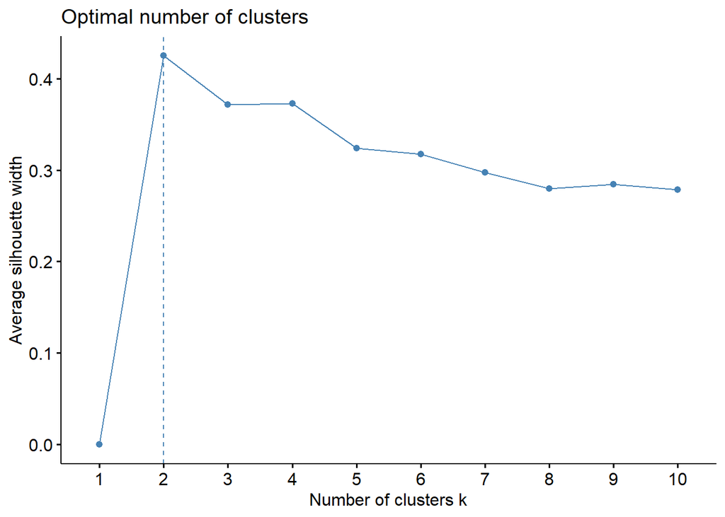

```r
# Ajustar estrutura do dataset
df_cluster <- as.data.frame(df_cluster)
rownames(df_cluster) <- df_cluster$id
df_cluster$id <- NULL
View(df_cluster)

# Normalizar dados
df_cluster_scaled <- scale(df_cluster, center = TRUE, scale = TRUE)
View(df_cluster_scaled)

# Encontrar número de clusters ideal de acordo com o método Silhouette
fviz_nbclust(df_cluster_scaled, kmeans, method = "silhouette")
```

```r
# Criar coluna Cluster no dataset principal
set.seed(1)
df_final_cluster <- df %>%
  mutate(cluster = factor(kmeans(df_cluster_scaled, centers = 2, nstart = 10)$cluster))

df <- df_final_cluster
```

Analisar clusters

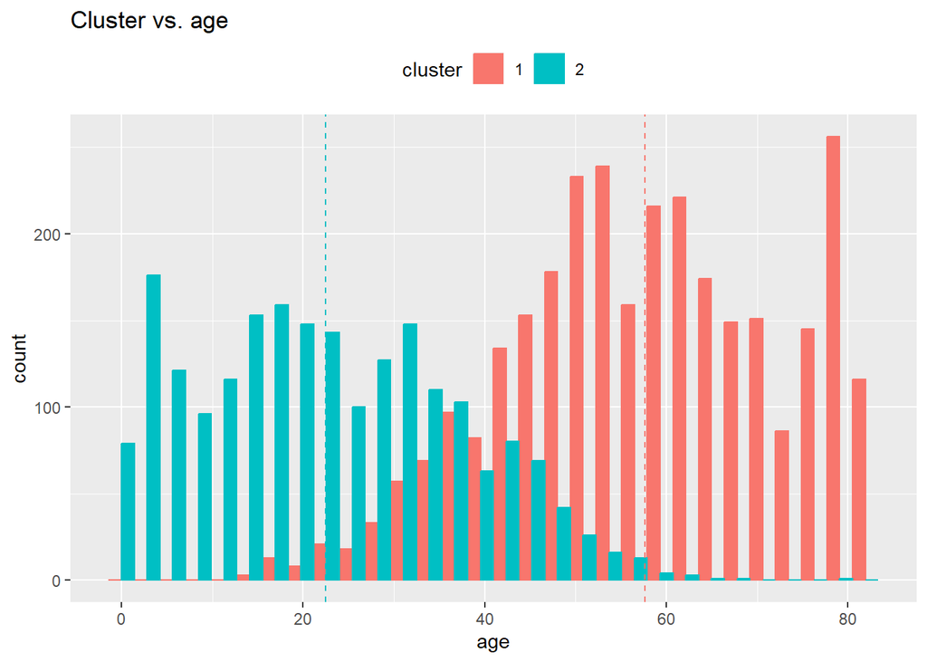

```r
# Calcular médias por cluster
medias <- df_final_cluster %>%
            group_by(cluster) %>%
              plotly::summarise(across(everything(), list(mean)))


# Plotar Cluster vs. age


df_final_cluster %>%
  ggplot(aes(x=age, color=cluster, fill=cluster)) +
  geom_histogram(position="dodge")+
  geom_vline(data=medias, aes(xintercept=age_1, color=cluster),
             linetype="dashed")+
  theme(legend.position="top")+
  labs(x = "age", title = "Cluster vs. age")
```

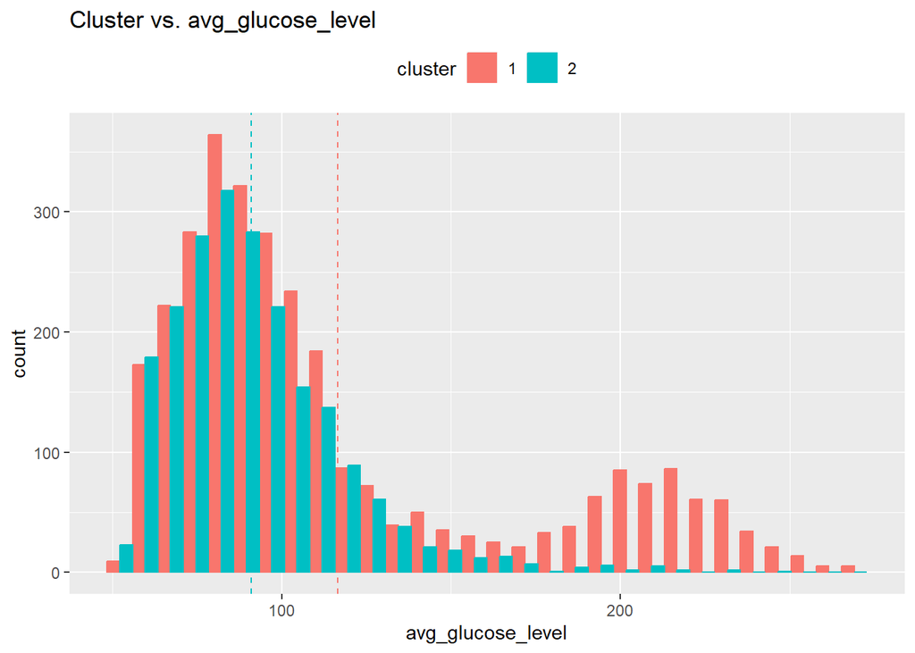

```r
# Plotar Cluster vs. avg_glucose_level

df_final_cluster %>%
  ggplot(aes(x=avg_glucose_level, color=cluster, fill=cluster)) +
  geom_histogram(position="dodge")+
  geom_vline(data=medias, aes(xintercept=avg_glucose_level_1, color=cluster),
             linetype="dashed")+
  theme(legend.position="top")+
  labs(x = "avg_glucose_level", title = "Cluster vs. avg_glucose_level")
```

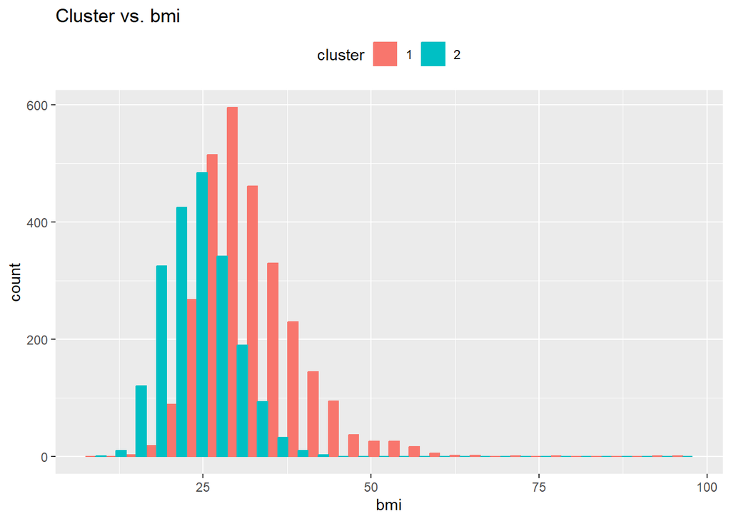

```r
# Plotar Cluster vs. bmi

df_final_cluster %>%
  ggplot(aes(x=bmi, color=cluster, fill=cluster)) +
  geom_histogram(position="dodge")+
  geom_vline(data=medias, aes(xintercept=bmi_1, color=cluster),
             linetype="dashed")+
  theme(legend.position="top")+
  labs(x = "bmi", title = "Cluster vs. bmi")
```

```r
# Plotar Cluster vs. stroke

df_grouped_stroke <- df_final_cluster %>%
  group_by(cluster,stroke) %>%
    plotly::summarise(total_count = n())


df_grouped_stroke %>%
  group_by(cluster) %>%
    plotly::summarise(pct_stroke = total_count / sum(total_count))
```

```
## # A tibble: 4 × 2
## # Groups:   cluster [2]
##   cluster pct_stroke
##   <fct>        <dbl>
## 1 1          0.920
## 2 1          0.0800
## 3 2          0.996
## 4 2          0.00381
```

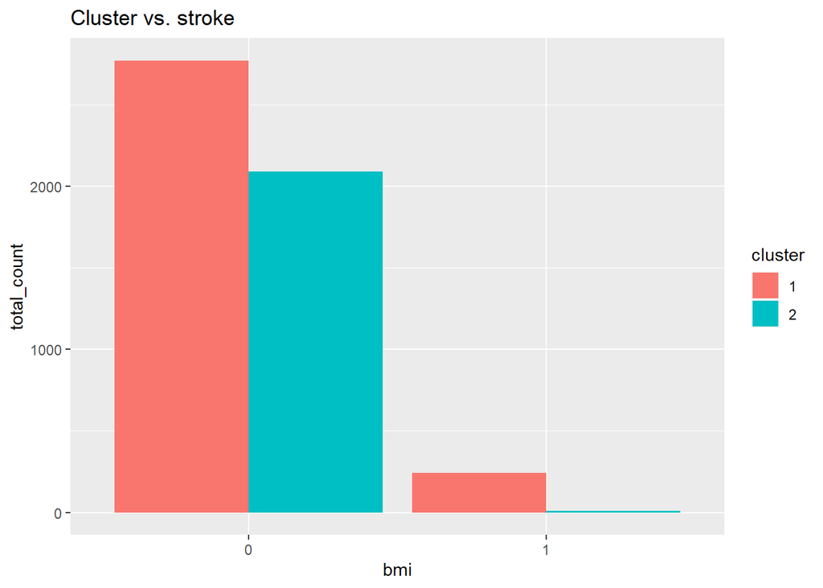

```r
df_grouped_stroke %>%
  ggplot(aes(x = stroke, y = total_count, fill = cluster)) +
    # Implement a grouped bar chart
  geom_bar(position = "dodge", stat = "identity")+
  labs(x = "bmi", title = "Cluster vs. stroke")
```

Podemos verificar que, em relação ao Cluster 2, no Cluster 1:

- As pessoas são bem mais velhas (a média é 58 x 22)
- As pessoas tem níveis de glicose mais altos (a média é 117 x 91)
- As pessoas tem níveis IMC (BMI) mais altos (a média é 32 x 24)
- AS pessoas sofrem mais infartos (8% x 0.4%)

# Análise Exploratória

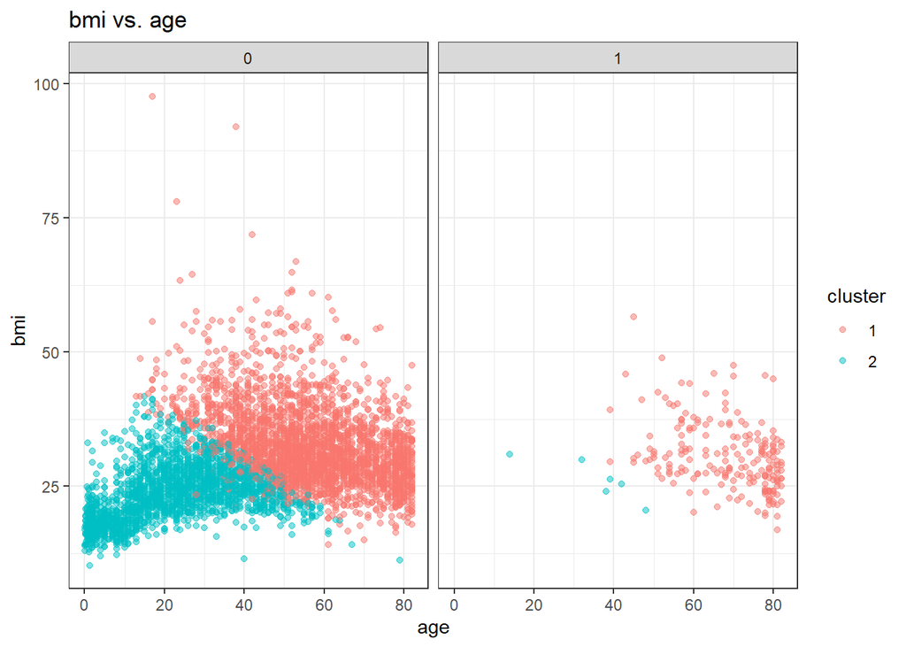

```r
# Plotar bmi vs. age
df_final_cluster %>%
  ggplot(aes(x=age, y=bmi,color=cluster, fill=cluster)) +
  geom_point(alpha=.5)+
  theme(legend.position="top")+
  labs(x = "age", y='bmi', title = "bmi vs. age")+
  theme_minimal()+
  theme_bw()+
  facet_grid(~ stroke, scale = "free_y")
```

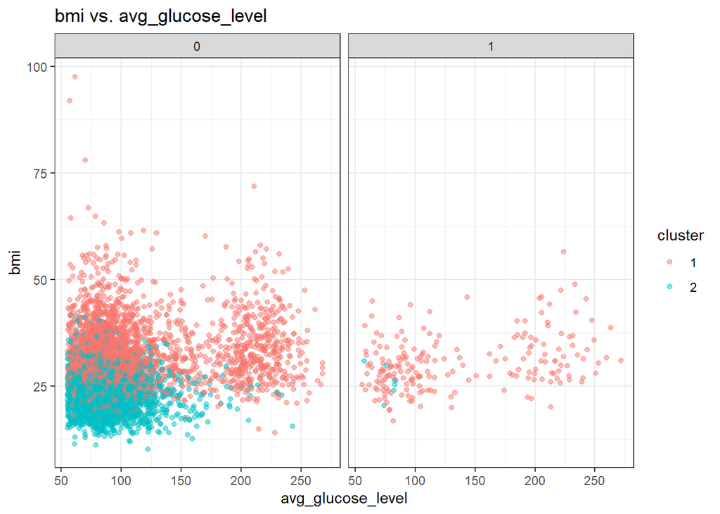

```r
# Plotar bmi vs. avg_glucose_level

df_final_cluster %>%
  ggplot(aes(x=avg_glucose_level, y=bmi,color=cluster, fill=cluster)) +
  geom_point(alpha=.5)+
  theme(legend.position="top")+
  labs(x = "avg_glucose_level", y='bmi', title = "bmi vs. avg_glucose_level")+
  theme_minimal()+
  theme_bw()+
  facet_grid(~ stroke, scale = "free_y")
```

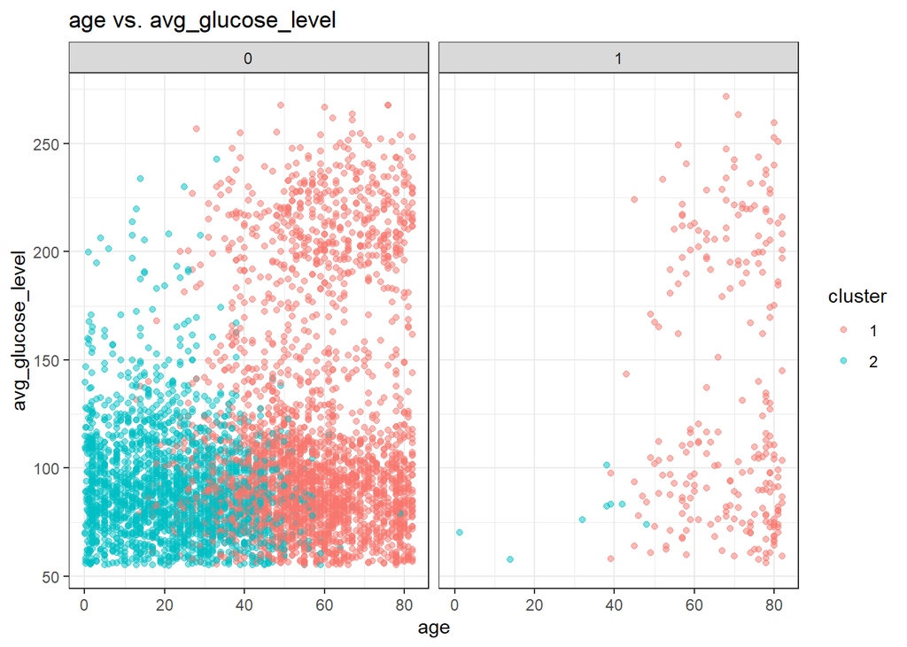

```r
# Plotar avg_glucose_level vs. age

df_final_cluster %>%
  ggplot(aes(x=age, y=avg_glucose_level,color=cluster, fill=cluster)) +
  geom_point(alpha=.5)+
  theme(legend.position="top")+
  labs(x = "age", y='avg_glucose_level', title = "age vs. avg_glucose_level")+
  theme_minimal()+
  theme_bw()+
  facet_grid(~ stroke, scale = "free_y")
```

```r
# Plotar gender vs. stroke

df_grouped_stroke_gender <- df_final_cluster %>%
  group_by(gender,stroke) %>%
    plotly::summarise(total_count = n())


df_grouped_stroke_gender %>%
  group_by(stroke) %>%
    plotly::summarise(pct_stroke = total_count / sum(total_count))
```

```
## # A tibble: 4 × 2
## # Groups:   stroke [2]
##   stroke pct_stroke
##   <fct>       <dbl>
## 1 0           0.587
## 2 0           0.413
## 3 1           0.566
## 4 1           0.434
```

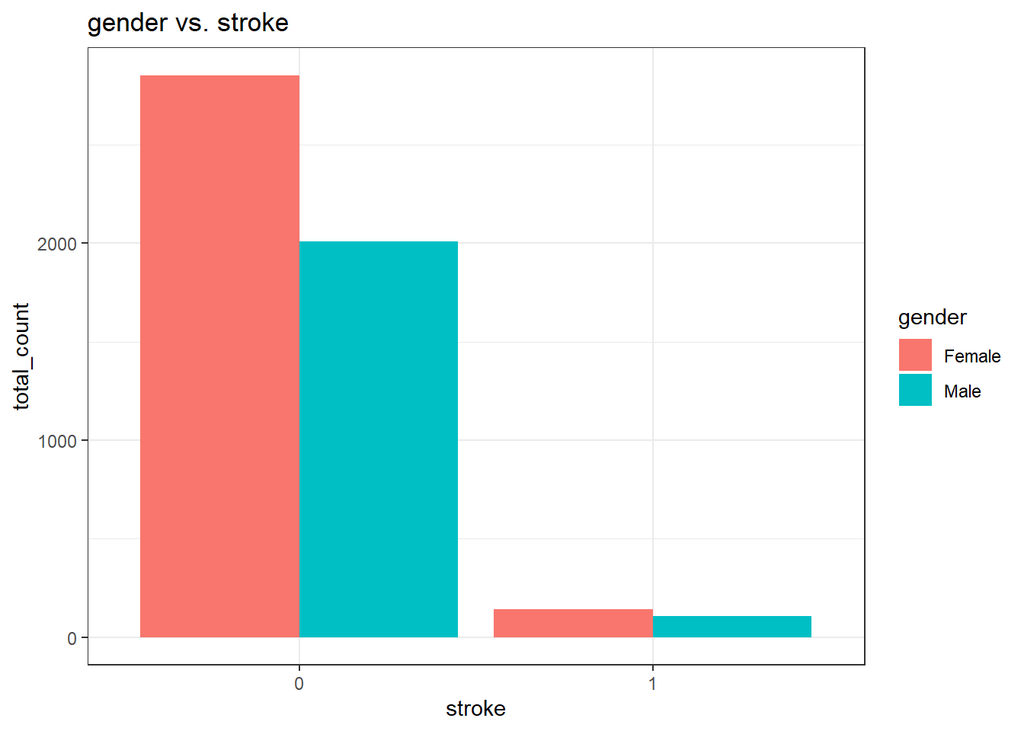

```r
df_grouped_stroke_gender %>%
  ggplot(aes(x = stroke  , y = total_count, fill = gender)) +
    # Implement a grouped bar chart
  geom_bar(position = "dodge", stat = "identity")+
  labs(x = "stroke", title = "gender vs. stroke")+
  theme_minimal()+
  theme_bw()
```

```r
# Plotar hypertension vs. stroke

df_grouped_stroke_hypertension <- df_final_cluster %>%
  group_by(hypertension,stroke) %>%
    plotly::summarise(total_count = n())


df_grouped_stroke_hypertension %>%
  group_by(stroke) %>%
    plotly::summarise(pct_stroke = total_count / sum(total_count))
```

```
## # A tibble: 4 × 2
## # Groups:   stroke [2]
##   stroke pct_stroke
##   <fct>       <dbl>
## 1 0          0.911
## 2 0          0.0889
## 3 1          0.735
## 4 1          0.265
```

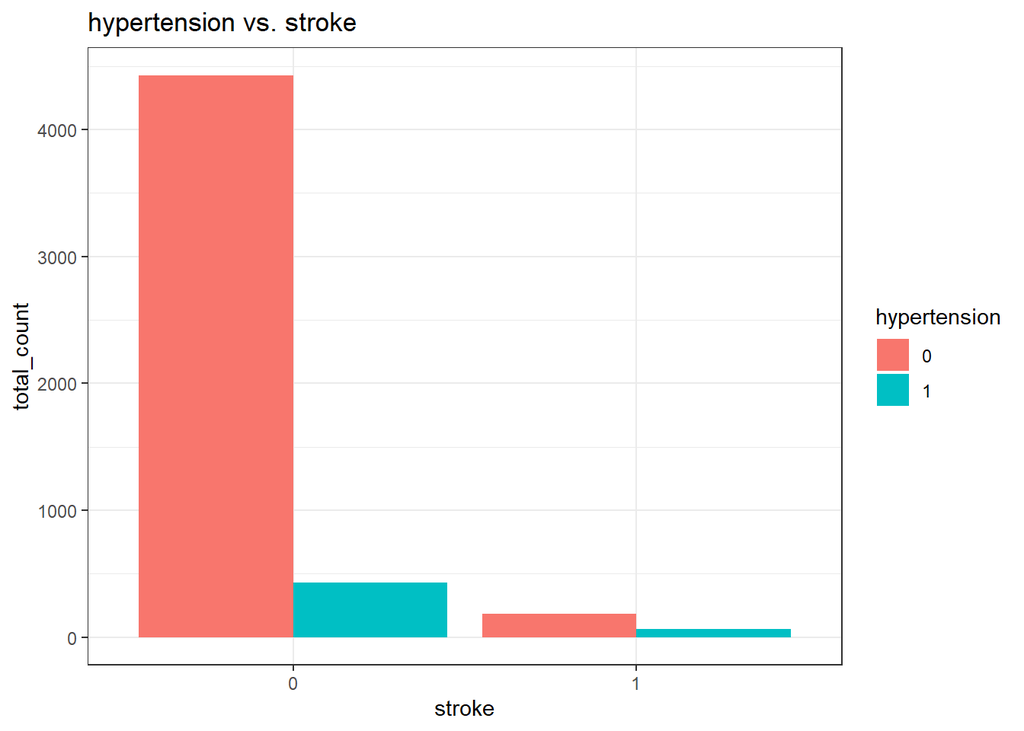

```r
df_grouped_stroke_hypertension %>%
  ggplot(aes(x = stroke  , y = total_count, fill = hypertension)) +
    # Implement a grouped bar chart
  geom_bar(position = "dodge", stat = "identity")+
  labs(x = "stroke", title = "hypertension vs. stroke")+
  theme_minimal()+
  theme_bw()
```

```r
# Plotar heart_disease vs. stroke

df_grouped_stroke_heart_disease <- df_final_cluster %>%
  group_by(heart_disease,stroke) %>%
    plotly::summarise(total_count = n())


df_grouped_stroke_heart_disease %>%
  group_by(stroke) %>%
    plotly::summarise(pct_stroke = total_count / sum(total_count))
```

```
## # A tibble: 4 × 2
## # Groups:   stroke [2]
##   stroke pct_stroke
##   <fct>       <dbl>
## 1 0          0.953
## 2 0          0.0471
## 3 1          0.811
## 4 1          0.189
```

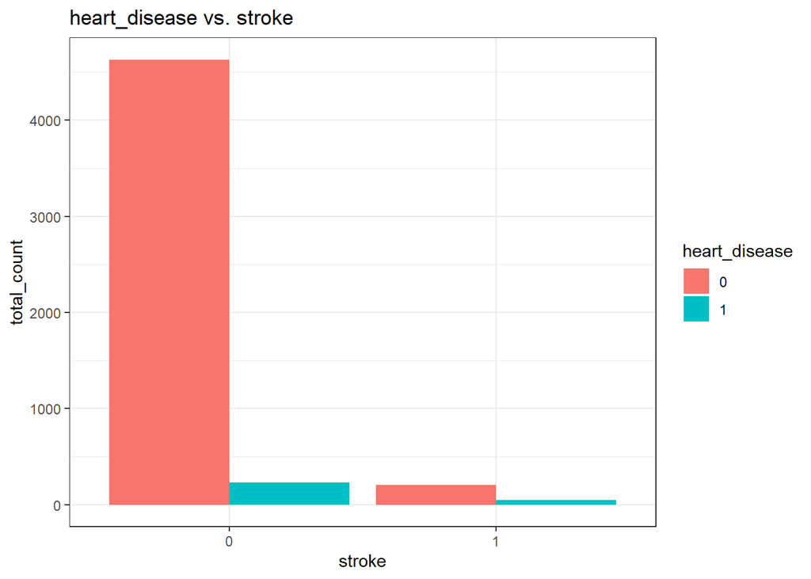

```r
df_grouped_stroke_heart_disease %>%
  ggplot(aes(x = stroke  , y = total_count, fill = heart_disease)) +
    # Implement a grouped bar chart
  geom_bar(position = "dodge", stat = "identity")+
  labs(x = "stroke", title = "heart_disease vs. stroke")+
  theme_minimal()+
  theme_bw()
```

```r
# Plotar ever_married vs. stroke

df_grouped_stroke_ever_married <- df_final_cluster %>%
  group_by(ever_married,stroke) %>%
    plotly::summarise(total_count = n())


df_grouped_stroke_ever_married %>%
  group_by(stroke) %>%
    plotly::summarise(pct_stroke = total_count / sum(total_count))
```

```
## # A tibble: 4 × 2
## # Groups:   stroke [2]
##   stroke pct_stroke
##   <fct>       <dbl>
## 1 0           0.355
## 2 0           0.645
## 3 1           0.116
## 4 1           0.884
```

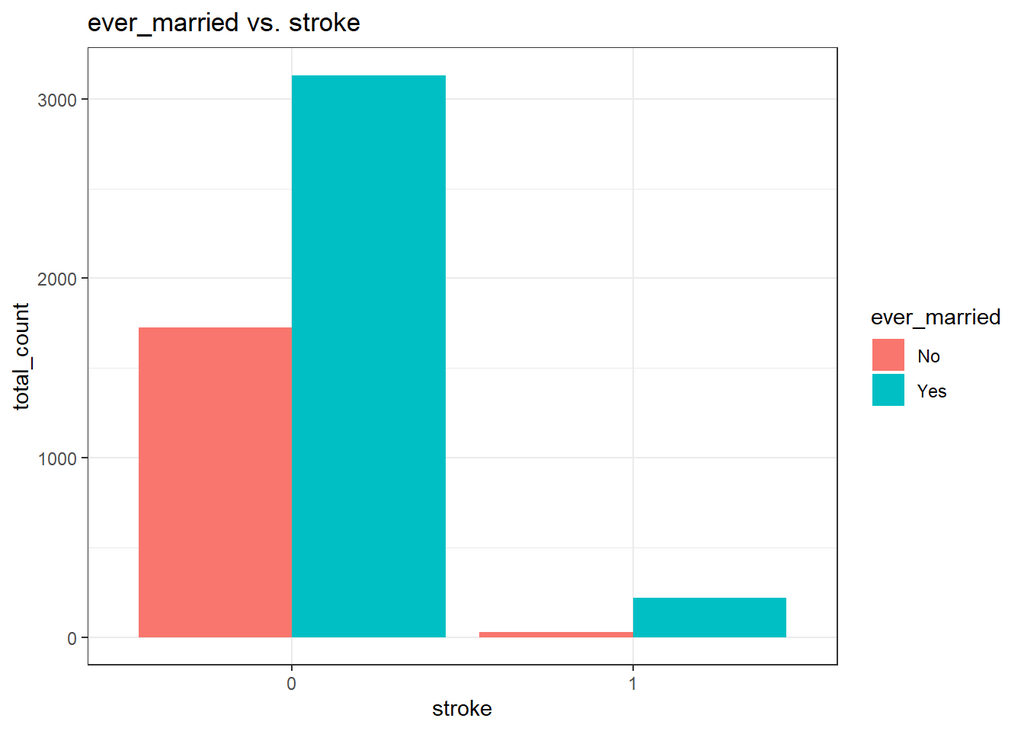

```r
df_grouped_stroke_ever_married %>%
  ggplot(aes(x = stroke  , y = total_count, fill = ever_married)) +
    # Implement a grouped bar chart
  geom_bar(position = "dodge", stat = "identity")+
  labs(x = "stroke", title = "ever_married vs. stroke")+
  theme_minimal()+
  theme_bw()
```

```r
# Plotar work_type vs. stroke

df_grouped_stroke_work_type <- df_final_cluster %>%
  group_by(work_type,stroke) %>%
    plotly::summarise(total_count = n())


df_grouped_stroke_work_type %>%
  group_by(stroke) %>%
    plotly::summarise(pct_stroke = total_count / sum(total_count))
```

```
## # A tibble: 9 × 2
## # Groups:   stroke [2]
##   stroke pct_stroke
##   <fct>       <dbl>
## 1 0         0.141
## 2 0         0.128
## 3 0         0.00453
## 4 0         0.571
## 5 0         0.155
## 6 1         0.00803
## 7 1         0.133
## 8 1         0.598
## 9 1         0.261
```

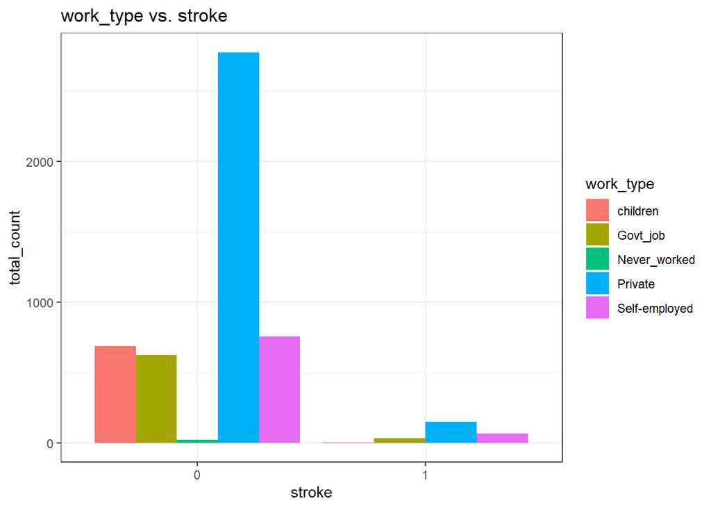

```r
df_grouped_stroke_work_type %>%
  ggplot(aes(x = stroke  , y = total_count, fill = work_type)) +
    # Implement a grouped bar chart
  geom_bar(position = "dodge", stat = "identity")+
  labs(x = "stroke", title = "work_type vs. stroke")+
  theme_minimal()+
  theme_bw()
```

```r
# Plotar Residence_type vs. stroke

df_grouped_stroke_Residence_type <- df_final_cluster %>%
  group_by(Residence_type,stroke) %>%
    plotly::summarise(total_count = n())


df_grouped_stroke_Residence_type %>%
  group_by(stroke) %>%
    plotly::summarise(pct_stroke = total_count / sum(total_count))
```

```
## # A tibble: 4 × 2
## # Groups:   stroke [2]
##   stroke pct_stroke
##   <fct>       <dbl>
## 1 0           0.494
## 2 0           0.506
## 3 1           0.458
## 4 1           0.542
```

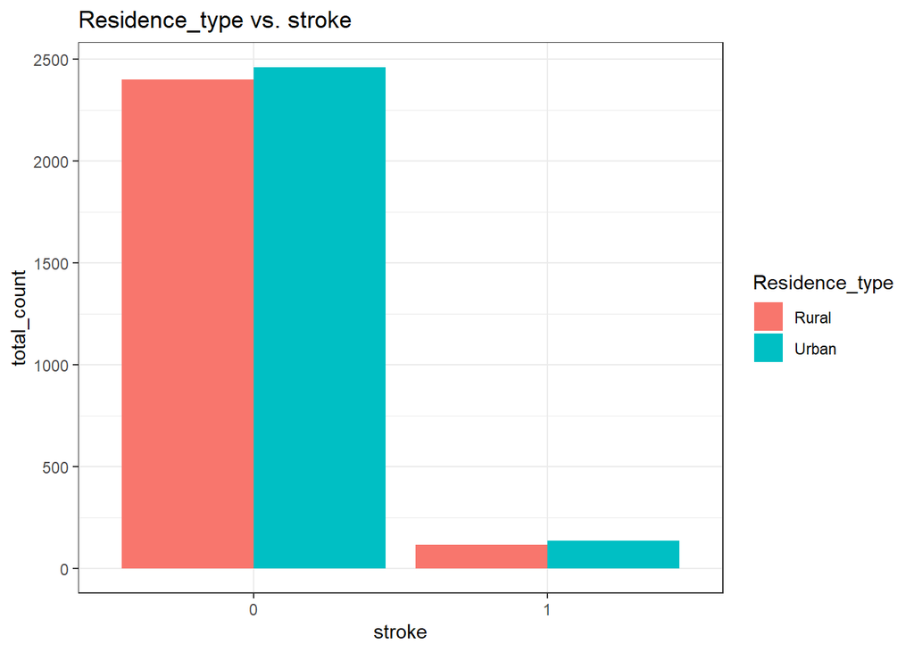

```r
df_grouped_stroke_Residence_type %>%
  ggplot(aes(x = stroke  , y = total_count, fill = Residence_type)) +
    # Implement a grouped bar chart
  geom_bar(position = "dodge", stat = "identity")+
  labs(x = "stroke", title = "Residence_type vs. stroke")+
  theme_minimal()+
  theme_bw()
```

```r
# Plotar smoking_status vs. stroke

df_grouped_stroke_smoking_status <- df_final_cluster %>%
  group_by(smoking_status,stroke) %>%
    plotly::summarise(total_count = n())


df_grouped_stroke_smoking_status %>%
  group_by(stroke) %>%
    plotly::summarise(pct_stroke = total_count / sum(total_count))
```

```
## # A tibble: 8 × 2
## # Groups:   stroke [2]
##   stroke pct_stroke
##   <fct>       <dbl>
## 1 0           0.167
## 2 0           0.371
## 3 0           0.154
## 4 0           0.308
## 5 1           0.281
## 6 1           0.361
## 7 1           0.169
## 8 1           0.189
```

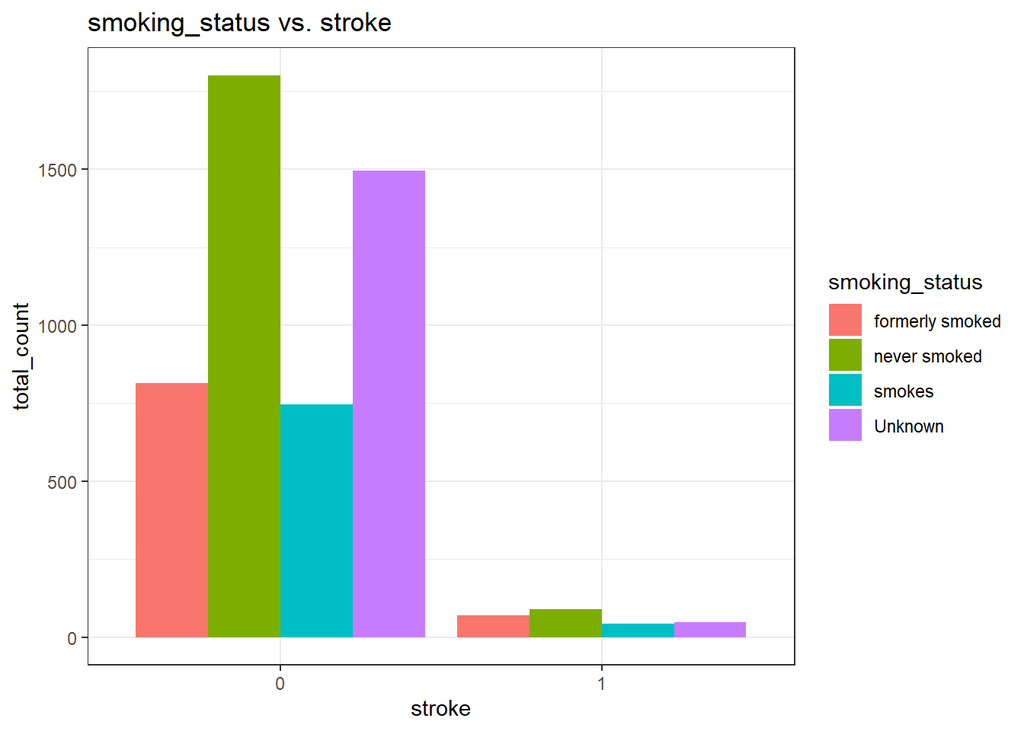

```r
df_grouped_stroke_smoking_status %>%
  ggplot(aes(x = stroke  , y = total_count, fill = smoking_status)) +
    # Implement a grouped bar chart
  geom_bar(position = "dodge", stat = "identity")+
  labs(x = "stroke", title = "smoking_status vs. stroke")+
  theme_minimal()+
  theme_bw()
```

Podemos verificar que:

- **Age x BMI**: Pessoas no cluster 1 são majoritariamente mais velhas e com valores mais altos de IMC, contendo quase todos os indivíduos que tiveram derrame;
- **BMI x avg_glucose_level e age x avg_glucose_level**: maior parte dos indivíduos do cluster 2 tem nível médio de glicose abaixo de 150, enquanto no cluster 1 parece haver uma separação mais equilibrada, tendo uma concentração entre 50 e 125, e outra entre 200 e 250;
- **Gender**: A proporção de homens e mulheres dentro dos grupos de pacientes que tiveram e não tiveram derrame é parecida, indicando que o gênero não possui muita relevância para ocorrência do evento;
- **hypertension**: Pacientes com hipertensão tem maior proporção dentro do grupo que apresentou derrame em relação ao que não apresentou (26% x 8%);
- **heart_disease**: Pacientes com doenças cardiacas tem maior proporção dentro do grupo que apresentou derrame em relação ao que não apresentou (18% x 4%);
- **ever_married**: Pacientes que são ou já foram casados tem maior proporção dentro do grupo que apresentou derrame em relação ao que não apresentou (88% x 64%);
- **work_type**: Pacientes que trabalham na área privada tem proporções parecidas dentro dos grupos que tiveram e não tiveram derrame, porém autônomos (‘Self-employed’) representam 26% do grupo com derrame enquanto são apenas 15% do grupo que não apresentou;
- **Residence_type**: A proporção de pacientes que vivem em area urbana e rural dentro dos grupos de que tiveram e não tiveram derrame é parecida, indicando que o o tipo de residência não possui muita relevância para ocorrência do evento;
- **smoking_status**: formerly smoked representam 28% do grupo com derrame enquanto são apenas 16% do grupo que não apresentou, demais categorias conhecidas possuem proporções semelhantes;

# Split da base em treino e teste

```r
set.seed(234)
split <- initial_split(df, prop = 0.8)
treinamento <- training(split)
teste <- testing(split)

#treinamento$stroke %>% table()
#teste$stroke %>% table()
```

# Criação do Tibble de Comparativo de Desempenho

Agora iremos criar um tibble para armazenar os resultados dos modelos

```r
desempenho <- tibble(
  prob = numeric(0),                 # número decimal
  classes = factor(character(0)),    # fator
  metodo = factor(character(0))      # fator
)
```

# Criação do recipe, prep e bake do tidymodels

```r
# Transformação de dados - formato tidymodels -------------------------------------

set.seed(234)
#faz a receita e prepara
(receita <- recipe(stroke ~ ., data = treinamento) %>%
   step_rm(id) %>%
   step_impute_median(bmi) %>%
   step_normalize(all_numeric(), -all_outcomes()) %>%
   step_other(all_nominal(), -all_outcomes(), threshold = .05, other = "outros") %>%
   step_dummy(all_nominal(), -all_outcomes(), one_hot = TRUE) %>%
   step_zv(all_predictors())
   )

(receita_prep <- prep(receita))

# obtem os dados de treinamento processados
treinamento_proc <- bake(receita_prep, new_data = NULL)

# obtem os dados de teste processados
teste_proc <- bake(receita_prep, new_data = teste)

# checando os dados processados
#skim(treinamento_proc)
#skim(teste_proc)

#treinamento_proc %>% ncol()
teste %>% ncol()
```

```
## [1] 14
```

```r
teste_proc %>% ncol()
```

```
## [1] 27
```

```r
teste %>% glimpse()
```

```
## Rows: 1,022
## Columns: 14
## $ id                <int> 60491, 5317, 34120, 68794, 64778, 54401, 62602, 7937…
## $ gender            <fct> Female, Female, Male, Female, Male, Male, Female, Ma…
## $ age               <dbl> 78, 79, 75, 79, 82, 80, 49, 60, 81, 78, 82, 56, 80, …
## $ hypertension      <fct> 0, 0, 1, 0, 0, 0, 0, 1, 0, 1, 0, 0, 1, 0, 0, 0, 1, 0…
## $ heart_disease     <fct> 0, 1, 0, 0, 1, 1, 0, 0, 0, 0, 0, 0, 0, 0, 0, 0, 0, 0…
## $ ever_married      <fct> Yes, Yes, Yes, Yes, Yes, Yes, Yes, Yes, Yes, Yes, Ye…
## $ work_type         <fct> Private, Private, Private, Self-employed, Private, S…
## $ Residence_type    <fct> Urban, Urban, Urban, Urban, Rural, Urban, Urban, Urb…
## $ avg_glucose_level <dbl> 58.57, 214.09, 221.29, 228.70, 208.30, 252.72, 60.91…
## $ bmi               <dbl> 24.2, 28.2, 25.8, 26.6, 32.5, 30.5, 29.9, 20.2, 33.7…
## $ smoking_status    <fct> Unknown, never smoked, smokes, never smoked, Unknown…
## $ stroke            <fct> 1, 1, 1, 1, 1, 1, 1, 1, 1, 1, 1, 1, 1, 1, 1, 1, 1, 1…
## $ flag              <fct> 0, 0, 0, 0, 0, 0, 0, 0, 0, 1, 0, 0, 0, 0, 0, 0, 0, 0…
## $ cluster           <fct> 1, 1, 1, 1, 1, 1, 1, 1, 1, 1, 1, 1, 1, 1, 1, 1, 1, 1…
```

```r
teste_proc %>% glimpse()
```

```
## Rows: 1,022
## Columns: 27
## $ age                            <dbl> 1.53594, 1.58028, 1.40294, 1.58028, 1.7…
## $ avg_glucose_level              <dbl> -1.0493, 2.3807, 2.5395, 2.7030, 2.2530…
## $ bmi                            <dbl> -0.60828, -0.08753, -0.39998, -0.29583,…
## $ stroke                         <fct> 1, 1, 1, 1, 1, 1, 1, 1, 1, 1, 1, 1, 1, …
## $ gender_Female                  <dbl> 1, 1, 0, 1, 0, 0, 1, 0, 0, 0, 1, 1, 1, …
## $ gender_Male                    <dbl> 0, 0, 1, 0, 1, 1, 0, 1, 1, 1, 0, 0, 0, …
## $ hypertension_X0                <dbl> 1, 1, 0, 1, 1, 1, 1, 0, 1, 0, 1, 1, 0, …
## $ hypertension_X1                <dbl> 0, 0, 1, 0, 0, 0, 0, 1, 0, 1, 0, 0, 1, …
## $ heart_disease_X0               <dbl> 1, 0, 1, 1, 0, 0, 1, 1, 1, 1, 1, 1, 1, …
## $ heart_disease_X1               <dbl> 0, 1, 0, 0, 1, 1, 0, 0, 0, 0, 0, 0, 0, …
## $ ever_married_No                <dbl> 0, 0, 0, 0, 0, 0, 0, 0, 0, 0, 0, 0, 0, …
## $ ever_married_Yes               <dbl> 1, 1, 1, 1, 1, 1, 1, 1, 1, 1, 1, 1, 1, …
## $ work_type_children             <dbl> 0, 0, 0, 0, 0, 0, 0, 0, 0, 0, 0, 0, 0, …
## $ work_type_Govt_job             <dbl> 0, 0, 0, 0, 0, 0, 0, 1, 0, 0, 0, 0, 0, …
## $ work_type_Private              <dbl> 1, 1, 1, 0, 1, 0, 1, 0, 0, 1, 1, 1, 1, …
## $ work_type_Self.employed        <dbl> 0, 0, 0, 1, 0, 1, 0, 0, 1, 0, 0, 0, 0, …
## $ work_type_outros               <dbl> 0, 0, 0, 0, 0, 0, 0, 0, 0, 0, 0, 0, 0, …
## $ Residence_type_Rural           <dbl> 0, 0, 0, 0, 1, 0, 0, 0, 0, 0, 1, 0, 1, …
## $ Residence_type_Urban           <dbl> 1, 1, 1, 1, 0, 1, 1, 1, 1, 1, 0, 1, 0, …
## $ smoking_status_formerly.smoked <dbl> 0, 0, 0, 0, 0, 1, 0, 0, 0, 1, 0, 1, 0, …
## $ smoking_status_never.smoked    <dbl> 0, 1, 0, 1, 0, 0, 1, 0, 1, 0, 1, 0, 1, …
## $ smoking_status_smokes          <dbl> 0, 0, 1, 0, 0, 0, 0, 1, 0, 0, 0, 0, 0, …
## $ smoking_status_Unknown         <dbl> 1, 0, 0, 0, 1, 0, 0, 0, 0, 0, 0, 0, 0, …
## $ flag_X0                        <dbl> 1, 1, 1, 1, 1, 1, 1, 1, 1, 0, 1, 1, 1, …
## $ flag_outros                    <dbl> 0, 0, 0, 0, 0, 0, 0, 0, 0, 1, 0, 0, 0, …
## $ cluster_X1                     <dbl> 1, 1, 1, 1, 1, 1, 1, 1, 1, 1, 1, 1, 1, …
## $ cluster_X2                     <dbl> 0, 0, 0, 0, 0, 0, 0, 0, 0, 0, 0, 0, 0, …
```

# Criação e ajuste dos modelos

### Modelo Random Forest

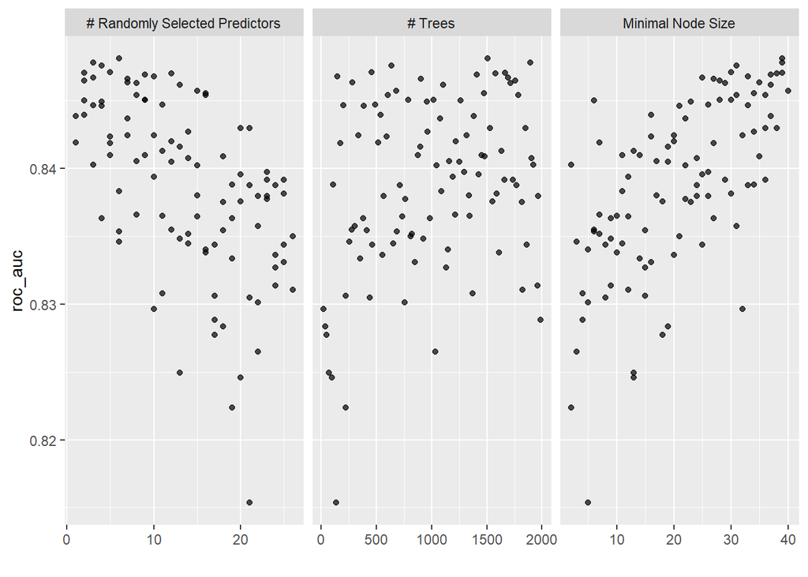

```r
# Definir os hiperparâmetros para tunagem
rf <- rand_forest(trees = tune(), mtry = tune(), min_n = tune()) %>%
  set_engine("ranger") %>%
  set_mode("classification")

# CV
set.seed(234)
cv_split <- vfold_cv(treinamento, v = 10)

# Paralelização
doParallel::registerDoParallel(makeCluster(16))

tempo <- system.time({
  rf_grid <- tune_grid(rf,
                       receita,
                       resamples = cv_split,
                       grid = 100,
                       metrics = metric_set(roc_auc))
})

autoplot(rf_grid)  # Plota os resultados do grid search
```

```r
rf_grid %>%
  collect_metrics() %>%   # Visualiza o tibble de resultados
  arrange(desc(mean))
```

```
## # A tibble: 100 × 9
##     mtry trees min_n .metric .estimator  mean     n std_err .config
##    <int> <int> <int> <chr>   <chr>      <dbl> <int>   <dbl> <chr>
##  1     6  1506    39 roc_auc binary     0.848    10 0.00914 Preprocessor1_Model…
##  2     3  1893    39 roc_auc binary     0.848    10 0.00870 Preprocessor1_Model…
##  3     4   634    31 roc_auc binary     0.848    10 0.00970 Preprocessor1_Model…
##  4     5   456    30 roc_auc binary     0.847    10 0.0101  Preprocessor1_Model…
##  5     2  1666    39 roc_auc binary     0.847    10 0.00875 Preprocessor1_Model…
##  6    12  1579    38 roc_auc binary     0.847    10 0.00802 Preprocessor1_Model…
##  7     9  1411    37 roc_auc binary     0.847    10 0.00869 Preprocessor1_Model…
##  8    10   148    33 roc_auc binary     0.847    10 0.00955 Preprocessor1_Model…
##  9     3  1692    25 roc_auc binary     0.847    10 0.00926 Preprocessor1_Model…
## 10     7   904    27 roc_auc binary     0.847    10 0.00883 Preprocessor1_Model…
## # ℹ 90 more rows
```

```r
# Seleciona o melhor conjunto de hiperparâmetros
best_rf <- rf_grid %>%
  select_best("roc_auc")

tempo #grid = 50, 106s
```

```
##    user  system elapsed
##    0.04    0.00  233.76
```

```r
# Faz o fit do modelo com o melhor conjunto de hiperparâmetros
rf_fit <- finalize_model(rf, parameters = best_rf) %>%
  fit(stroke ~ ., data = treinamento_proc)

pred_rf <- predict(rf_fit, new_data = teste_proc, type = "prob")$.pred_1

desempenho <- desempenho %>%
                bind_rows(tibble(prob = pred_rf,
                                classes = ifelse(teste_proc$stroke == "1", "Yes", "No"),
                                metodo = "Random Forest"))

# visualizando variáveis mais importantes
#vip(rf_fit)
```

### Modelo XGBOOST

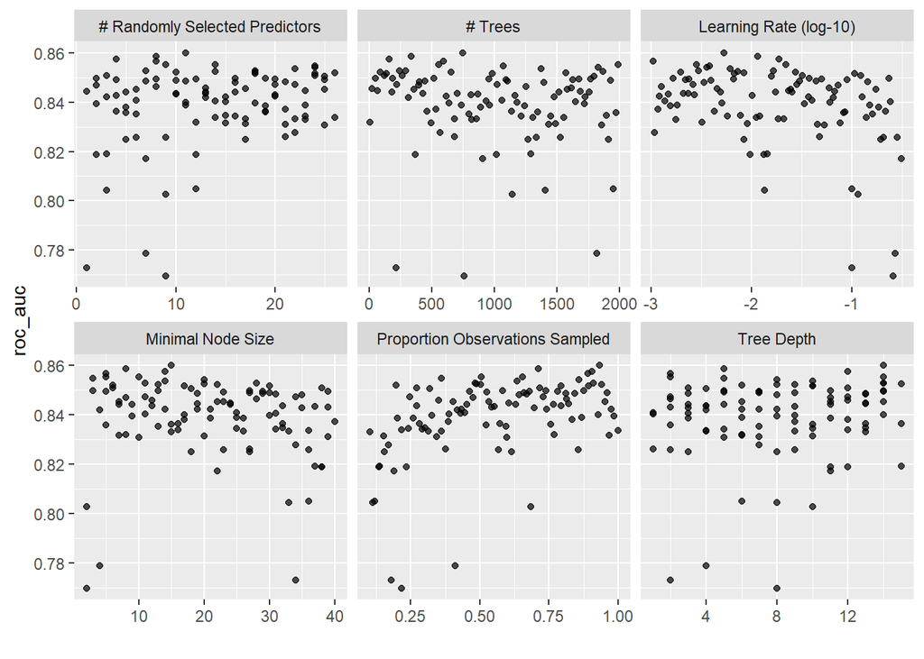

```r
boost <- boost_tree(trees = tune(), learn_rate = tune(), mtry = tune(),
                    tree_depth = tune(), min_n = tune(), sample_size = tune()) %>%
  set_engine("xgboost") %>%
  set_mode("classification")

# cv
set.seed(234)
cv_split <- vfold_cv(treinamento, v = 10)

# otimização de hiperparametro
doParallel::registerDoParallel(16) #colocar nro de cores da maquina

tempo <- system.time({
  boost_grid <- tune_grid(boost,
                          receita,
                          resamples = cv_split,
                          grid = 100,
                          metrics = metric_set(roc_auc))
})

autoplot(boost_grid) # plota os resultados do grid search
```

```r
boost_grid %>%
  collect_metrics()  %>%   # visualiza o tibble de resultados
  arrange(desc(mean))
```

```
## # A tibble: 100 × 12
##     mtry trees min_n tree_depth learn_rate sample_size .metric .estimator  mean
##    <int> <int> <int>      <int>      <dbl>       <dbl> <chr>   <chr>      <dbl>
##  1    11   749    15         14    0.00536       0.934 roc_auc binary     0.860
##  2     8   335     8          5    0.0116        0.710 roc_auc binary     0.859
##  3     4   158    14         12    0.0189        0.906 roc_auc binary     0.857
##  4     8   592     5          2    0.00104       0.891 roc_auc binary     0.857
##  5     9  1988    10         14    0.00285       0.506 roc_auc binary     0.855
##  6    14   554     5          2    0.0220        0.655 roc_auc binary     0.855
##  7    24  1072     3          5    0.00381       0.360 roc_auc binary     0.855
##  8    24  1830    20          8    0.00360       0.858 roc_auc binary     0.854
##  9    22  1375    14         10    0.00613       0.634 roc_auc binary     0.853
## 10    18   290    28         14    0.0166        0.910 roc_auc binary     0.853
## # ℹ 90 more rows
## # ℹ 3 more variables: n <int>, std_err <dbl>, .config <chr>
```

```r
(best_xgb <- boost_grid %>%
    select_best("roc_auc")) # salva o melhor conjunto de parametros
```

```
## # A tibble: 1 × 7
##    mtry trees min_n tree_depth learn_rate sample_size .config
##   <int> <int> <int>      <int>      <dbl>       <dbl> <chr>
## 1    11   749    15         14    0.00536       0.934 Preprocessor1_Model039
```

```r
tempo #grid = 50, 161s
```

```
##    user  system elapsed
##    0.23    0.00  309.80
```

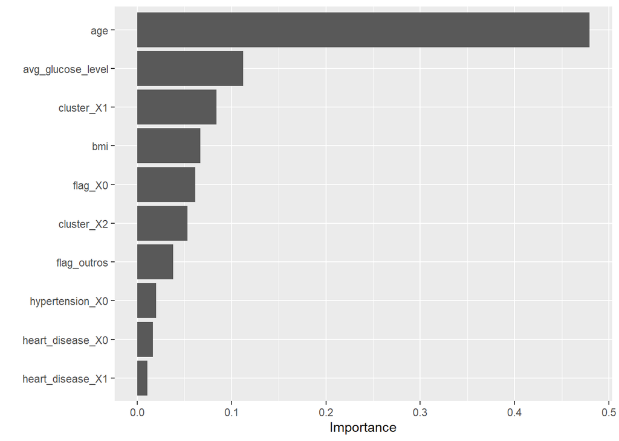

```r
#faz o fit do modelo com o melhor conjunto de hiperparâmetros
boost_fit <- finalize_model(boost, parameters = best_xgb) %>%
  fit(stroke ~ ., treinamento_proc)

pred_xgbm <- predict(boost_fit, new_data = teste_proc, type = "prob")$.pred_1

desempenho <- desempenho %>%
                bind_rows(tibble(prob = pred_xgbm,
                                classes = ifelse(teste_proc$stroke == "1", "Yes", "No"),
                                metodo = "XGBM"))

# visualizando variáveis mais importantes
vip(boost_fit)
```

### Redes Neurais

Definição de estrutura e loading de pesos treinados

```r
X_trn <- treinamento_proc %>% dplyr::select(-stroke) %>% as.matrix()
X_tst <- teste_proc %>% dplyr::select(-stroke) %>% as.matrix()

y_trn <- treinamento_proc$stroke %>% to_categorical()
y_tst <- teste_proc$stroke %>% to_categorical()

# Modelo Sequencial
net <- keras_model_sequential() %>%
  layer_dense(units = 512, activation = "relu", input_shape = ncol(X_trn)) %>%
  layer_dropout(rate = 0.4) %>%
  layer_dense(units = 256, activation = "relu") %>%
  layer_dropout(rate = 0.4) %>%
  layer_dense(units = 128, activation = "relu") %>%
  layer_dropout(rate = 0.3) %>%
  layer_dense(units = 64, activation = "relu") %>%
  layer_dropout(rate = 0.2) %>%
  layer_dense(units = 32, activation = "relu") %>%
  layer_dropout(rate = 0.2) %>%
  layer_dense(units = 16, activation = "relu") %>%
  layer_dropout(rate = 0.1) %>%
  layer_dense(units = 2, activation = "softmax")  # Camada de saída com ativação sigmoid


# definicao do estimador da rede neural
net %>%
  compile(loss = "categorical_crossentropy",
          optimizer = optimizer_rmsprop(),
          metrics = c("Recall")
          )

#accuracy Recall(sensibilidade) Precision

summary(net)
```

Treina o modelo de redes neurais e salva

```r
tensorflow::set_random_seed(123)

# Definindo o callback de Early Stopping
callback <- callback_early_stopping(
  monitor = "val_loss",  # Métrica a ser monitorada
  patience = 20,          # Número de épocas para esperar após a parada de melhorias
  restore_best_weights = TRUE)  # Restaura os pesos do modelo para a melhor época


history <- net %>%
  fit(X_trn, y_trn, epochs = 10000,
      batch_size = 80, validation_split = 0.2, #DIVIDE O TOTAL DE DADOS EM 80 BLOCOS
      callbacks = list(callback)) #pega 20% pra validar enquanto roda

#plot(history)

# Salvando os pesos do modelo
save_model_weights_hdf5(net, "C:/Users/arnch/OneDrive/Documentos/Insper/meus_pesos_modelo.h5")
```

```r
# Carregando os pesos salvos no modelo
net %>% load_model_weights_hdf5("C:/Users/arnch/OneDrive/Documentos/Insper/meus_pesos_modelo.h5")

pred_nn <- predict(net, X_tst)[,2] #prob de apresentar o evento
```

```
## 32/32 - 0s - 86ms/epoch - 3ms/step
```

mede e compara

```r
desempenho <- desempenho %>%
                bind_rows(tibble(prob = pred_nn,
                                classes = ifelse(teste_proc$stroke == "1", "Yes", "No"),
                                metodo = "Neural Networks"))
```

### Modelo de redes neurais com 40 epocas (sem call back)

Treina o modelo de redes neurais e salva

```r
tensorflow::set_random_seed(42)

history <- net %>%
  fit(X_trn, y_trn, epochs = 40,
      batch_size = 80, validation_split = 0.2)

pred_nn_2 <- predict(net, X_tst)[,2] #prob de apresentar o evento
```

mede e compara

```r
desempenho <- desempenho %>%
                bind_rows(tibble(prob = pred_nn_2,
                                classes = ifelse(teste_proc$stroke == "1", "Yes", "No"),
                                metodo = "Neural Networks - sem callback"))

desempenho %>%
  mutate(classes = factor(classes)) %>%
  group_by(metodo) %>%
  roc_auc(classes, prob, event_level = "second") %>%
  arrange(desc(.estimate))
```

```
## # A tibble: 4 × 4
##   metodo                         .metric .estimator .estimate
##   <chr>                          <chr>   <chr>          <dbl>
## 1 XGBM                           roc_auc binary         0.821
## 2 Neural Networks                roc_auc binary         0.814
## 3 Random Forest                  roc_auc binary         0.803
## 4 Neural Networks - sem callback roc_auc binary         0.775
```

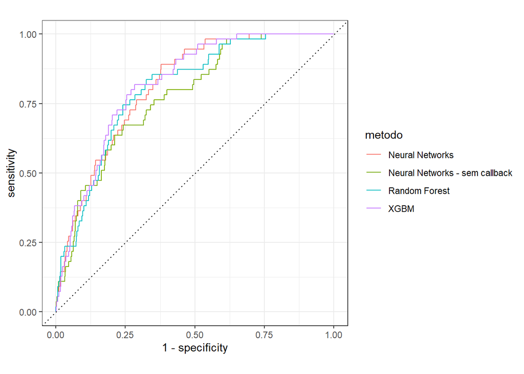

```r
desempenho %>%
  mutate(classes = factor(classes)) %>%
  group_by(metodo) %>%
  roc_curve(classes, prob, event_level = "second") %>%
  autoplot()
```

# Análise aprofundada dos modelos e pontos de corte

Para mensurar o melhor ponto de corte definimos uma variavel chamada “campo” que é o produto de ppv por sensibilidade. Para dar uma importancia maior para sensibilidade elevamos ela ao cubo. Para ficar mais fácil de vizualisar o resultado final multiplicamos por 100. Ordenamos em ordem decrescente os 3 principais pontos de corte. Estamos considerando todos os gráficos pois, não necessariamente o modelo com maior auc será o melhor para nosso problema em questão.

Random Forest:

```r
coords(roc(teste_proc$stroke, pred_rf), c(seq(.001,.009,.001), seq(.01,.2,.01),seq(.3,.5,.1)),
       ret = c("threshold","accuracy", "sensitivity", "1-specificity", "ppv", "npv")) %>%
       mutate(campo = 100 * ppv * sensitivity^3)  %>% arrange(desc(campo)) %>% head(3) #quanto menor a sensibilidade mais penaliza
```

```
##   threshold accuracy sensitivity 1-specificity     ppv    npv campo
## 1     0.005   0.4295      0.9636        0.6008 0.08360 0.9948 7.480
## 2     0.003   0.3777      0.9818        0.6567 0.07837 0.9970 7.418
## 3     0.030   0.6781      0.8364        0.3309 0.12568 0.9863 7.353
```

Extreme Gradient Boosting

```r
coords(roc(teste_proc$stroke, pred_xgbm), c(seq(.001,.009,.001), seq(.01,.2,.01),seq(.3,.5,.1)),
       ret = c("threshold","accuracy", "sensitivity", "1-specificity", "ppv", "npv")) %>%
       mutate(campo = 100 * ppv * sensitivity^3)  %>% arrange(desc(campo)) %>% head(3)
```

```
##   threshold accuracy sensitivity 1-specificity     ppv    npv campo
## 1      0.02   0.5313      0.9273        0.4912 0.09696 0.9919 7.730
## 2      0.05   0.7231      0.8000        0.2813 0.13924 0.9844 7.129
## 3      0.03   0.6155      0.8545        0.3981 0.10880 0.9864 6.789
```

Neural Networks

```r
coords(roc(teste_proc$stroke, pred_nn), c(seq(.001,.009,.001), seq(.01,.2,.01),seq(.3,.5,.1)),
       ret = c("threshold","accuracy", "sensitivity", "1-specificity", "ppv", "npv")) %>%
       mutate(campo = 100 * ppv * sensitivity^3)  %>% arrange(desc(campo)) %>% head(3)
```

```
##   threshold accuracy sensitivity 1-specificity     ppv    npv campo
## 1     0.006   0.4765      0.9818        0.5522 0.09184 0.9977 8.692
## 2     0.005   0.4618      0.9818        0.5677 0.08955 0.9976 8.476
## 3     0.007   0.4902      0.9636        0.5367 0.09266 0.9956 8.291
```

Calculo manual do ppv

```r
threshold <- 0.006

previsoes_1 <- ifelse(pred_nn >= threshold, 1, 0) %>% as.tibble

previsoes_1 <- previsoes_1 %>%
                bind_cols(tibble(obs = teste_proc$stroke))

#calculo manual do PPV
previsoes_1 %>% dplyr::filter(value == 1) %>% dplyr::select(obs) %>% table()
```

```
## obs
##   0   1
## 534  54
```

```r
#Percentual de exames diminuidos
(1-(previsoes_1 %>% dplyr::filter(value == 1) %>% nrow()/nrow(previsoes_1)))*100
```

```
## [1] 42.47
```

Conclusão: ao fazer exame somente nos casos com 0.6% ou mais de probabilidade de ter derrame, estaremos diminuindo em aproximadamente 42% a quantidade de exames necessárias enquanto somente 2% de pessoas que terão derrames não serão contempladas. Levando a ganhos consideraveis para o hospital e ganhos indiretos aos pacientes, uma vez que com menos pacientes na fila os exames teoricamente devem sair mais rápido.

De que forma podemos obter ganhos diretos para os pacientes? E se quisermos dar prioridade para casos de alto risco?

```r
coords(roc(teste_proc$stroke, pred_rf), .2,
       ret = c("threshold","accuracy", "sensitivity", "1-specificity", "ppv", "npv")) %>%
       mutate(campo = 100 * ppv * sensitivity^3)  %>% arrange(desc(campo)) %>% head(3) #quanto menor a sensibilidade mais penaliza
```

```
##           threshold accuracy sensitivity 1-specificity    ppv    npv  campo
## threshold       0.2   0.9198      0.2364       0.04137 0.2453 0.9567 0.3239
```

```r
coords(roc(teste_proc$stroke, pred_xgbm), .2,
       ret = c("threshold","accuracy", "sensitivity", "1-specificity", "ppv", "npv")) %>%
       mutate(campo = 100 * ppv * sensitivity^3)
```

```
##           threshold accuracy sensitivity 1-specificity  ppv    npv campo
## threshold       0.2   0.9188         0.2       0.04033 0.22 0.9547 0.176
```

```r
coords(roc(teste_proc$stroke, pred_nn), .2,
       ret = c("threshold","accuracy", "sensitivity", "1-specificity", "ppv", "npv")) %>%
       mutate(campo = 100 * ppv * sensitivity^3)
```

```
##           threshold accuracy sensitivity 1-specificity    ppv    npv campo
## threshold       0.2    0.911      0.2727       0.05274 0.2273 0.9582 0.461
```

Redes Neurais obteve a melhor nota para o corte de 20%

```r
threshold <- 0.2 #20%

previsoes_2 <- ifelse(pred_nn >= threshold, 1, 0) %>% as.tibble %>% setNames("valor2")

lista_prioritaria <- teste_proc %>%
                bind_cols(previsoes_1) %>% bind_cols(previsoes_2)

lista_prioritaria  <- lista_prioritaria %>% mutate(resultado=ifelse(value == 1, "em risco", "sem risco"),
                                                   resultado = ifelse(valor2 == 1, "urgente", resultado)) %>% dplyr::select(-value, -valor2)

lista_prioritaria$resultado %>% table()
```

```
## .
##  em risco sem risco   urgente
##       522       434        66
```

Geramos uma lista onde marcamos se o paciente vai precisar ou não fazer exame, e caso ele precise marcamos como “urgente” pacientes com igual ou mais de 20% de probabilidade de apresentar derrame.